# Bike-Share2

Yan

14/12/2022

## Google Data Analyst Certificate Capstone Project

Estudo feito utilizando base de dados fictícia com dados históricos de ciclistas.

Objetivo do estudo é responder as seguintes questões: 1- Como os membros anuais e os ciclistas casuais usam as bicicletas ciclísticas de maneira diferente? 2- Por que os ciclistas casuais comprariam associações anuais ciclísticas? 3- Como a Cyclistic pode usar a mídia digital para influenciar ciclistas casuais a se tornarem membros?

## Código

Primeiro vamos importar as bibliotecas que serão utilizadas.

```r
library(tidyverse)
library(lubridate)
library(readxl)
```

Agora incluir as tabelas que serão utilizadas.

```r
Nov_21 <- read_csv("E:/Cursos/Google Data Analyst Certificate/8 - Capstone Project/Case Study 1/Dados/202111-divvy-tripdata.csv")
Dez_21 <- read_csv("E:/Cursos/Google Data Analyst Certificate/8 - Capstone Project/Case Study 1/Dados/202112-divvy-tripdata.csv")
Jan_22 <- read_csv("E:/Cursos/Google Data Analyst Certificate/8 - Capstone Project/Case Study 1/Dados/202201-divvy-tripdata.csv")
Fev_22 <- read_csv("E:/Cursos/Google Data Analyst Certificate/8 - Capstone Project/Case Study 1/Dados/202202-divvy-tripdata.csv")
Mar_22 <- read_csv("E:/Cursos/Google Data Analyst Certificate/8 - Capstone Project/Case Study 1/Dados/202203-divvy-tripdata.csv")
Abr_22 <- read_csv("E:/Cursos/Google Data Analyst Certificate/8 - Capstone Project/Case Study 1/Dados/202204-divvy-tripdata.csv")
Mai_22 <- read_csv("E:/Cursos/Google Data Analyst Certificate/8 - Capstone Project/Case Study 1/Dados/202205-divvy-tripdata.csv")
Jun_22 <- read_csv("E:/Cursos/Google Data Analyst Certificate/8 - Capstone Project/Case Study 1/Dados/202206-divvy-tripdata.csv")
Jul_22 <- read_csv("E:/Cursos/Google Data Analyst Certificate/8 - Capstone Project/Case Study 1/Dados/202207-divvy-tripdata.csv")
Ago_22 <- read_csv("E:/Cursos/Google Data Analyst Certificate/8 - Capstone Project/Case Study 1/Dados/202208-divvy-tripdata.csv")
Set_22 <- read_csv("E:/Cursos/Google Data Analyst Certificate/8 - Capstone Project/Case Study 1/Dados/202209-divvy-publictripdata.csv")
Out_22 <- read_csv("E:/Cursos/Google Data Analyst Certificate/8 - Capstone Project/Case Study 1/Dados/202210-divvy-tripdata.csv")
```

Conferindo se os nomes das colunas estão iguais para poder juntar em uma só tabela

```r
colnames(Nov_21)
```

```
##  [1] "ride_id"            "rideable_type"      "started_at"
##  [4] "ended_at"           "start_station_name" "start_station_id"
##  [7] "end_station_name"   "end_station_id"     "start_lat"
## [10] "start_lng"          "end_lat"            "end_lng"
## [13] "member_casual"
```

```r
colnames(Dez_21)
```

```
##  [1] "ride_id"            "rideable_type"      "started_at"
##  [4] "ended_at"           "start_station_name" "start_station_id"
##  [7] "end_station_name"   "end_station_id"     "start_lat"
## [10] "start_lng"          "end_lat"            "end_lng"
## [13] "member_casual"
```

```r
colnames(Jan_22)
```

```
##  [1] "ride_id"            "rideable_type"      "started_at"
##  [4] "ended_at"           "start_station_name" "start_station_id"
##  [7] "end_station_name"   "end_station_id"     "start_lat"
## [10] "start_lng"          "end_lat"            "end_lng"
## [13] "member_casual"
```

```r
colnames(Fev_22)
```

```
##  [1] "ride_id"            "rideable_type"      "started_at"
##  [4] "ended_at"           "start_station_name" "start_station_id"
##  [7] "end_station_name"   "end_station_id"     "start_lat"
## [10] "start_lng"          "end_lat"            "end_lng"
## [13] "member_casual"
```

```r
colnames(Mar_22)
```

```
##  [1] "ride_id"            "rideable_type"      "started_at"
##  [4] "ended_at"           "start_station_name" "start_station_id"
##  [7] "end_station_name"   "end_station_id"     "start_lat"
## [10] "start_lng"          "end_lat"            "end_lng"
## [13] "member_casual"
```

```r
colnames(Abr_22)
```

```
##  [1] "ride_id"            "rideable_type"      "started_at"
##  [4] "ended_at"           "start_station_name" "start_station_id"
##  [7] "end_station_name"   "end_station_id"     "start_lat"
## [10] "start_lng"          "end_lat"            "end_lng"
## [13] "member_casual"
```

```r
colnames(Mai_22)
```

```
##  [1] "ride_id"            "rideable_type"      "started_at"
##  [4] "ended_at"           "start_station_name" "start_station_id"
##  [7] "end_station_name"   "end_station_id"     "start_lat"
## [10] "start_lng"          "end_lat"            "end_lng"
## [13] "member_casual"
```

```r
colnames(Jun_22)
```

```
##  [1] "ride_id"            "rideable_type"      "started_at"
##  [4] "ended_at"           "start_station_name" "start_station_id"
##  [7] "end_station_name"   "end_station_id"     "start_lat"
## [10] "start_lng"          "end_lat"            "end_lng"
## [13] "member_casual"
```

```r
colnames(Jul_22)
```

```
##  [1] "ride_id"            "rideable_type"      "started_at"
##  [4] "ended_at"           "start_station_name" "start_station_id"
##  [7] "end_station_name"   "end_station_id"     "start_lat"
## [10] "start_lng"          "end_lat"            "end_lng"
## [13] "member_casual"
```

```r
colnames(Ago_22)
```

```
##  [1] "ride_id"            "rideable_type"      "started_at"
##  [4] "ended_at"           "start_station_name" "start_station_id"
##  [7] "end_station_name"   "end_station_id"     "start_lat"
## [10] "start_lng"          "end_lat"            "end_lng"
## [13] "member_casual"
```

```r
colnames(Set_22)
```

```
##  [1] "ride_id"            "rideable_type"      "started_at"
##  [4] "ended_at"           "start_station_name" "start_station_id"
##  [7] "end_station_name"   "end_station_id"     "start_lat"
## [10] "start_lng"          "end_lat"            "end_lng"
## [13] "member_casual"
```

```r
colnames(Out_22)
```

```
##  [1] "ride_id"            "rideable_type"      "started_at"
##  [4] "ended_at"           "start_station_name" "start_station_id"
##  [7] "end_station_name"   "end_station_id"     "start_lat"
## [10] "start_lng"          "end_lat"            "end_lng"
## [13] "member_casual"
```

```r
dados_ano <- rbind(Nov_21,Dez_21,Jan_22,Fev_22,Mar_22,Abr_22,Mai_22,Jun_22,Jul_22,Ago_22,Set_22,Out_22)
head(dados_ano)
```

```
## # A tibble: 6 x 13
##   ride_id rideable_type started_at          ended_at            start_station_n~
##   <chr>   <chr>         <dttm>              <dttm>              <chr>
## 1 7C00A9~ electric_bike 2021-11-27 13:27:38 2021-11-27 13:46:38 <NA>
## 2 908548~ electric_bike 2021-11-27 13:38:25 2021-11-27 13:56:10 <NA>
## 3 0A7D10~ electric_bike 2021-11-26 22:03:34 2021-11-26 22:05:56 <NA>
## 4 2F3BE3~ electric_bike 2021-11-27 09:56:49 2021-11-27 10:01:50 <NA>
## 5 D67B47~ electric_bike 2021-11-26 19:09:28 2021-11-26 19:30:41 <NA>
## 6 02F85C~ electric_bike 2021-11-26 18:34:07 2021-11-26 18:52:49 Michigan Ave & ~
## # ... with 8 more variables: start_station_id <chr>, end_station_name <chr>,
## #   end_station_id <chr>, start_lat <dbl>, start_lng <dbl>, end_lat <dbl>,
## #   end_lng <dbl>, member_casual <chr>
```

```r
str(dados_ano)
```

```
## spec_tbl_df [5,755,694 x 13] (S3: spec_tbl_df/tbl_df/tbl/data.frame)
##  $ ride_id           : chr [1:5755694] "7C00A93E10556E47" "90854840DFD508BA" "0A7D10CDD144061C" "2F3BE33085BCFF02" ...
##  $ rideable_type     : chr [1:5755694] "electric_bike" "electric_bike" "electric_bike" "electric_bike" ...
##  $ started_at        : POSIXct[1:5755694], format: "2021-11-27 13:27:38" "2021-11-27 13:38:25" ...
##  $ ended_at          : POSIXct[1:5755694], format: "2021-11-27 13:46:38" "2021-11-27 13:56:10" ...
##  $ start_station_name: chr [1:5755694] NA NA NA NA ...
##  $ start_station_id  : chr [1:5755694] NA NA NA NA ...
##  $ end_station_name  : chr [1:5755694] NA NA NA NA ...
##  $ end_station_id    : chr [1:5755694] NA NA NA NA ...
##  $ start_lat         : num [1:5755694] 41.9 42 42 41.9 41.9 ...
##  $ start_lng         : num [1:5755694] -87.7 -87.7 -87.7 -87.8 -87.6 ...
##  $ end_lat           : num [1:5755694] 42 41.9 42 41.9 41.9 ...
##  $ end_lng           : num [1:5755694] -87.7 -87.7 -87.7 -87.8 -87.6 ...
##  $ member_casual     : chr [1:5755694] "casual" "casual" "casual" "casual" ...
##  - attr(*, "spec")=
##   .. cols(
##   ..   ride_id = col_character(),
##   ..   rideable_type = col_character(),
##   ..   started_at = col_datetime(format = ""),
##   ..   ended_at = col_datetime(format = ""),
##   ..   start_station_name = col_character(),
##   ..   start_station_id = col_character(),
##   ..   end_station_name = col_character(),
##   ..   end_station_id = col_character(),
##   ..   start_lat = col_double(),
##   ..   start_lng = col_double(),
##   ..   end_lat = col_double(),
##   ..   end_lng = col_double(),
##   ..   member_casual = col_character()
##   .. )
##  - attr(*, "problems")=<externalptr>
```

Retirando as observações com NA da base.

```r
dados_ano2 <- drop_na(dados_ano)
head(dados_ano2)
```

```
## # A tibble: 6 x 13
##   ride_id rideable_type started_at          ended_at            start_station_n~
##   <chr>   <chr>         <dttm>              <dttm>              <chr>
## 1 4CA967~ classic_bike  2021-11-26 10:27:28 2021-11-26 11:22:13 Michigan Ave & ~
## 2 F3E84A~ classic_bike  2021-11-15 09:35:03 2021-11-15 09:42:08 Clark St & Grac~
## 3 A1F2C9~ electric_bike 2021-11-10 16:27:02 2021-11-10 17:04:28 Leamington Ave ~
## 4 9B871C~ classic_bike  2021-11-09 19:51:36 2021-11-09 20:11:17 Desplaines St &~
## 5 2A81E9~ classic_bike  2021-11-06 19:14:10 2021-11-06 19:33:19 Larrabee St & A~
## 6 A57F8F~ electric_bike 2021-11-18 11:58:24 2021-11-18 12:08:35 Michigan Ave & ~
## # ... with 8 more variables: start_station_id <chr>, end_station_name <chr>,
## #   end_station_id <chr>, start_lat <dbl>, start_lng <dbl>, end_lat <dbl>,
## #   end_lng <dbl>, member_casual <chr>
```

```r
nrow(dados_ano)
```

```
## [1] 5755694
```

```r
nrow(dados_ano2)
```

```
## [1] 4410438
```

```r
N_NA <- nrow(dados_ano)-nrow(dados_ano2)
paste(N_NA, "linhas com NA retiradas") ## Como mesmo retirando essas linhas ainda temos um volume grande para analisar, mantive essa análise.
```

```
## [1] "1345256 linhas com NA retiradas"
```

```r
anyNA(dados_ano2)
```

```
## [1] FALSE
```

Criando novas variáveis (ride_length, week_day, month e year)

```r
dados_ano2$ride_length <- difftime(dados_ano2$ended_at,dados_ano2$started_at)
dados_ano2$ride_length <- as.numeric(dados_ano2$ride_length)
dados_ano2$week_day <- weekdays(dados_ano2$started_at)
dados_ano2$month <- month(dados_ano2$started_at)
dados_ano2$year <- year(dados_ano2$started_at)
```

Tabulando algumas variáveis para saber os tipos de respostas que temos.

```r
table(dados_ano2$member_casual)
```

```
##
##  casual  member
## 1768182 2642256
```

```r
table(dados_ano2$week_day)
```

```
##
##       domingo  quarta-feira  quinta-feira        sábado segunda-feira
##        609133        617576        639252        720914        600200
##   sexta-feira   terça-feira
##        614787        608576
```

```r
table(dados_ano2$month)
```

```
##
##      1      2      3      4      5      6      7      8      9     10     11
##  80128  89178 215983 272560 502545 620350 642680 605325 535145 414269 255904
##     12
## 176371
```

```r
table(dados_ano2$year)
```

```
##
##    2021    2022
##  432275 3978163
```

```r
head(dados_ano2)
```

```
## # A tibble: 6 x 17
##   ride_id rideable_type started_at          ended_at            start_station_n~
##   <chr>   <chr>         <dttm>              <dttm>              <chr>
## 1 4CA967~ classic_bike  2021-11-26 10:27:28 2021-11-26 11:22:13 Michigan Ave & ~
## 2 F3E84A~ classic_bike  2021-11-15 09:35:03 2021-11-15 09:42:08 Clark St & Grac~
## 3 A1F2C9~ electric_bike 2021-11-10 16:27:02 2021-11-10 17:04:28 Leamington Ave ~
## 4 9B871C~ classic_bike  2021-11-09 19:51:36 2021-11-09 20:11:17 Desplaines St &~
## 5 2A81E9~ classic_bike  2021-11-06 19:14:10 2021-11-06 19:33:19 Larrabee St & A~
## 6 A57F8F~ electric_bike 2021-11-18 11:58:24 2021-11-18 12:08:35 Michigan Ave & ~
## # ... with 12 more variables: start_station_id <chr>, end_station_name <chr>,
## #   end_station_id <chr>, start_lat <dbl>, start_lng <dbl>, end_lat <dbl>,
## #   end_lng <dbl>, member_casual <chr>, ride_length <dbl>, week_day <chr>,
## #   month <dbl>, year <dbl>
```

```r
str(dados_ano2)
```

```
## tibble [4,410,438 x 17] (S3: tbl_df/tbl/data.frame)
##  $ ride_id           : chr [1:4410438] "4CA9676997DAFFF6" "F3E84A230AF2D676" "A1F2C92308007968" "9B871C3B14E9BEC4" ...
##  $ rideable_type     : chr [1:4410438] "classic_bike" "classic_bike" "electric_bike" "classic_bike" ...
##  $ started_at        : POSIXct[1:4410438], format: "2021-11-26 10:27:28" "2021-11-15 09:35:03" ...
##  $ ended_at          : POSIXct[1:4410438], format: "2021-11-26 11:22:13" "2021-11-15 09:42:08" ...
##  $ start_station_name: chr [1:4410438] "Michigan Ave & Oak St" "Clark St & Grace St" "Leamington Ave & Hirsch St" "Desplaines St & Kinzie St" ...
##  $ start_station_id  : chr [1:4410438] "13042" "TA1307000127" "307" "TA1306000003" ...
##  $ end_station_name  : chr [1:4410438] "Michigan Ave & Oak St" "Clark St & Leland Ave" "Leamington Ave & Hirsch St" "Desplaines St & Kinzie St" ...
##  $ end_station_id    : chr [1:4410438] "13042" "TA1309000014" "307" "TA1306000003" ...
##  $ start_lat         : num [1:4410438] 41.9 42 41.9 41.9 41.9 ...
##  $ start_lng         : num [1:4410438] -87.6 -87.7 -87.8 -87.6 -87.6 ...
##  $ end_lat           : num [1:4410438] 41.9 42 41.9 41.9 41.9 ...
##  $ end_lng           : num [1:4410438] -87.6 -87.7 -87.8 -87.6 -87.6 ...
##  $ member_casual     : chr [1:4410438] "casual" "casual" "casual" "casual" ...
##  $ ride_length       : num [1:4410438] 3285 425 2246 1181 1149 ...
##  $ week_day          : chr [1:4410438] "sexta-feira" "segunda-feira" "quarta-feira" "terça-feira" ...
##  $ month             : num [1:4410438] 11 11 11 11 11 11 11 11 11 11 ...
##  $ year              : num [1:4410438] 2021 2021 2021 2021 2021 ...
```

```r
summary(dados_ano2) ## Observamos que em ride_length há alguns casos com número negativo já que o min deu -10.122
```

```
##    ride_id          rideable_type        started_at
##  Length:4410438     Length:4410438     Min.   :2021-11-01 00:00:14
##  Class :character   Class :character   1st Qu.:2022-05-02 12:46:15
##  Mode  :character   Mode  :character   Median :2022-06-30 17:52:01
##                                        Mean   :2022-06-15 05:39:32
##                                        3rd Qu.:2022-08-24 06:56:28
##                                        Max.   :2022-10-31 23:59:33
##     ended_at                   start_station_name start_station_id
##  Min.   :2021-11-01 00:04:06   Length:4410438     Length:4410438
##  1st Qu.:2022-05-02 13:00:55   Class :character   Class :character
##  Median :2022-06-30 18:08:17   Mode  :character   Mode  :character
##  Mean   :2022-06-15 05:56:47
##  3rd Qu.:2022-08-24 07:06:09
##  Max.   :2022-11-01 08:59:46
##  end_station_name   end_station_id       start_lat       start_lng
##  Length:4410438     Length:4410438     Min.   :41.65   Min.   :-87.83
##  Class :character   Class :character   1st Qu.:41.88   1st Qu.:-87.66
##  Mode  :character   Mode  :character   Median :41.90   Median :-87.64
##                                        Mean   :41.90   Mean   :-87.64
##                                        3rd Qu.:41.93   3rd Qu.:-87.63
##                                        Max.   :45.64   Max.   :-73.80
##     end_lat         end_lng       member_casual       ride_length
##  Min.   :41.65   Min.   :-87.83   Length:4410438     Min.   : -10122
##  1st Qu.:41.88   1st Qu.:-87.66   Class :character   1st Qu.:    365
##  Median :41.90   Median :-87.64   Mode  :character   Median :    640
##  Mean   :41.90   Mean   :-87.65                      Mean   :   1034
##  3rd Qu.:41.93   3rd Qu.:-87.63                      3rd Qu.:   1147
##  Max.   :42.06   Max.   :-87.53                      Max.   :2061244
##    week_day             month             year
##  Length:4410438     Min.   : 1.000   Min.   :2021
##  Class :character   1st Qu.: 5.000   1st Qu.:2022
##  Mode  :character   Median : 7.000   Median :2022
##                     Mean   : 7.134   Mean   :2022
##                     3rd Qu.: 9.000   3rd Qu.:2022
##                     Max.   :12.000   Max.   :2022
```

Tem algumas observações preenchidas em start_station_name com “HQ QR”, isso significa que são bicicletas que foram retiradas de suas bases e foram feitas checagem de qualidade, ou seja, retiraremos da análise esses casos. Retiraremos os casos em que ride_length foR menor que 0.

```r
dados_ano3 <- subset(dados_ano2, start_station_name != "HQ QR" & ride_length > 0)
head(dados_ano3)
```

```
## # A tibble: 6 x 17
##   ride_id rideable_type started_at          ended_at            start_station_n~
##   <chr>   <chr>         <dttm>              <dttm>              <chr>
## 1 4CA967~ classic_bike  2021-11-26 10:27:28 2021-11-26 11:22:13 Michigan Ave & ~
## 2 F3E84A~ classic_bike  2021-11-15 09:35:03 2021-11-15 09:42:08 Clark St & Grac~
## 3 A1F2C9~ electric_bike 2021-11-10 16:27:02 2021-11-10 17:04:28 Leamington Ave ~
## 4 9B871C~ classic_bike  2021-11-09 19:51:36 2021-11-09 20:11:17 Desplaines St &~
## 5 2A81E9~ classic_bike  2021-11-06 19:14:10 2021-11-06 19:33:19 Larrabee St & A~
## 6 A57F8F~ electric_bike 2021-11-18 11:58:24 2021-11-18 12:08:35 Michigan Ave & ~
## # ... with 12 more variables: start_station_id <chr>, end_station_name <chr>,
## #   end_station_id <chr>, start_lat <dbl>, start_lng <dbl>, end_lat <dbl>,
## #   end_lng <dbl>, member_casual <chr>, ride_length <dbl>, week_day <chr>,
## #   month <dbl>, year <dbl>
```

```r
summary(dados_ano3)
```

```
##    ride_id          rideable_type        started_at
##  Length:4410143     Length:4410143     Min.   :2021-11-01 00:00:14
##  Class :character   Class :character   1st Qu.:2022-05-02 12:45:48
##  Mode  :character   Mode  :character   Median :2022-06-30 17:51:40
##                                        Mean   :2022-06-15 05:39:44
##                                        3rd Qu.:2022-08-24 06:56:08
##                                        Max.   :2022-10-31 23:59:33
##     ended_at                   start_station_name start_station_id
##  Min.   :2021-11-01 00:04:06   Length:4410143     Length:4410143
##  1st Qu.:2022-05-02 13:00:28   Class :character   Class :character
##  Median :2022-06-30 18:07:50   Mode  :character   Mode  :character
##  Mean   :2022-06-15 05:56:59
##  3rd Qu.:2022-08-24 07:05:47
##  Max.   :2022-11-01 08:59:46
##  end_station_name   end_station_id       start_lat       start_lng
##  Length:4410143     Length:4410143     Min.   :41.65   Min.   :-87.83
##  Class :character   Class :character   1st Qu.:41.88   1st Qu.:-87.66
##  Mode  :character   Mode  :character   Median :41.90   Median :-87.64
##                                        Mean   :41.90   Mean   :-87.64
##                                        3rd Qu.:41.93   3rd Qu.:-87.63
##                                        Max.   :45.64   Max.   :-73.80
##     end_lat         end_lng       member_casual       ride_length
##  Min.   :41.65   Min.   :-87.83   Length:4410143     Min.   :      1
##  1st Qu.:41.88   1st Qu.:-87.66   Class :character   1st Qu.:    365
##  Median :41.90   Median :-87.64   Mode  :character   Median :    640
##  Mean   :41.90   Mean   :-87.65                      Mean   :   1035
##  3rd Qu.:41.93   3rd Qu.:-87.63                      3rd Qu.:   1147
##  Max.   :42.06   Max.   :-87.53                      Max.   :2061244
##    week_day             month             year
##  Length:4410143     Min.   : 1.000   Min.   :2021
##  Class :character   1st Qu.: 5.000   1st Qu.:2022
##  Mode  :character   Median : 7.000   Median :2022
##                     Mean   : 7.134   Mean   :2022
##                     3rd Qu.: 9.000   3rd Qu.:2022
##                     Max.   :12.000   Max.   :2022
```

Abaixo utilizei a função aggregate para gerar a informação de algumas estatísticas por algumas variáveis. Por exemplo, no primeiro código, geramos a média de ride_length por member_casual. Ou seja, conseguimos saber o tempo médio de corrida de quem é membro e de quem é casual.

```r
aggregate(dados_ano3$ride_length ~ dados_ano3$member_casual, FUN = mean)
```

```
##   dados_ano3$member_casual dados_ano3$ride_length
## 1                   casual              1464.0021
## 2                   member               747.2626
```

```r
aggregate(dados_ano3$ride_length ~ dados_ano3$member_casual, FUN = median)
```

```
##   dados_ano3$member_casual dados_ano3$ride_length
## 1                   casual                    841
## 2                   member                    540
```

```r
aggregate(dados_ano3$ride_length ~ dados_ano3$member_casual, FUN = max)
```

```
##   dados_ano3$member_casual dados_ano3$ride_length
## 1                   casual                2061244
## 2                   member                  89575
```

```r
aggregate(dados_ano3$ride_length ~ dados_ano3$member_casual, FUN = min)
```

```
##   dados_ano3$member_casual dados_ano3$ride_length
## 1                   casual                      1
## 2                   member                      1
```

```r
aggregate(dados_ano3$ride_length ~ dados_ano3$member_casual + dados_ano3$week_day, FUN = mean)
```

```
##    dados_ano3$member_casual dados_ano3$week_day dados_ano3$ride_length
## 1                    casual             domingo              1658.4200
## 2                    member             domingo               832.2913
## 3                    casual        quarta-feira              1272.1113
## 4                    member        quarta-feira               710.2178
## 5                    casual        quinta-feira              1313.2478
## 6                    member        quinta-feira               720.9707
## 7                    casual              sábado              1617.5181
## 8                    member              sábado               841.8271
## 9                    casual       segunda-feira              1516.7378
## 10                   member       segunda-feira               720.8370
## 11                   casual         sexta-feira              1360.8030
## 12                   member         sexta-feira               732.6892
## 13                   casual         terça-feira              1311.2150
## 14                   member         terça-feira               706.9231
```

```r
dados_ano3$week_day <- ordered(dados_ano3$week_day, levels=c( "segunda-feira", "terça-feira", "quarta-feira", "quinta-feira", "sexta-feira", "sábado", "domingo"))
aggregate(dados_ano3$ride_length ~ dados_ano3$member_casual + dados_ano3$week_day, FUN = mean)
```

```
##    dados_ano3$member_casual dados_ano3$week_day dados_ano3$ride_length
## 1                    casual       segunda-feira              1516.7378
## 2                    member       segunda-feira               720.8370
## 3                    casual         terça-feira              1311.2150
## 4                    member         terça-feira               706.9231
## 5                    casual        quarta-feira              1272.1113
## 6                    member        quarta-feira               710.2178
## 7                    casual        quinta-feira              1313.2478
## 8                    member        quinta-feira               720.9707
## 9                    casual         sexta-feira              1360.8030
## 10                   member         sexta-feira               732.6892
## 11                   casual              sábado              1617.5181
## 12                   member              sábado               841.8271
## 13                   casual             domingo              1658.4200
## 14                   member             domingo               832.2913
```

Abaixo criamos alguns gráficos de coluna para visualizar algumas métricas como número de passeios e média de tempo de passeio por variáveis como member_casual, week_day e rideable_type.

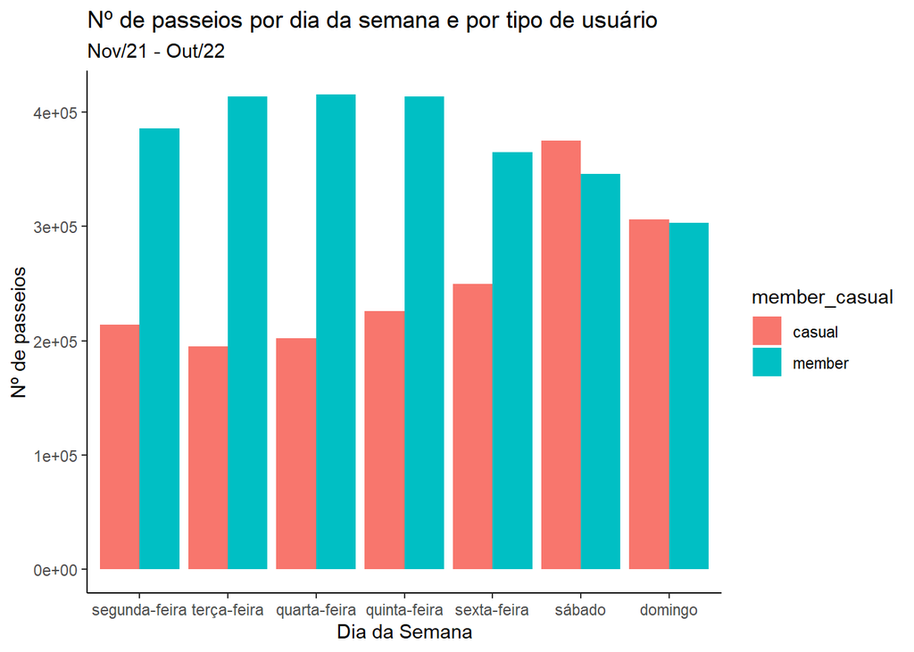

```r
dados_ano3 %>%
  group_by(member_casual, week_day) %>%
  summarise(number_of_rides = n()) %>%
  arrange(member_casual, week_day)  %>%
  ggplot(aes(x = week_day, y = number_of_rides, fill = member_casual)) + geom_col(position = "dodge") + theme_classic() + labs(title = "Nº de passeios por dia da semana e por tipo de usuário",
                                                                                                                               subtitle = "Nov/21 - Out/22", x = "Dia da Semana", y = "Nº de passeios")
```

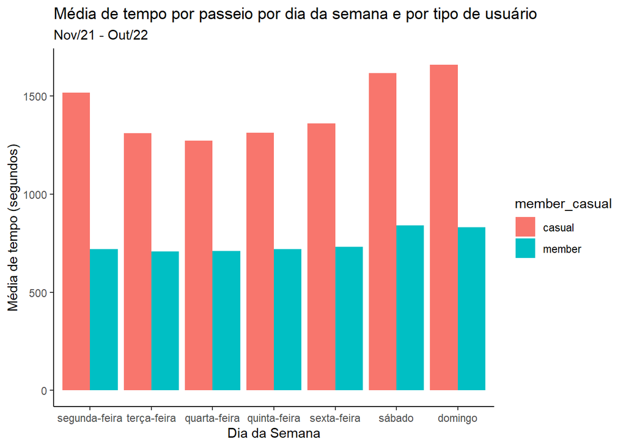

```r
dados_ano3 %>%
  group_by(member_casual, week_day) %>%
  summarise(average_duration = mean(ride_length)) %>%
  arrange(member_casual, week_day)  %>%
  ggplot(aes(x = week_day, y = average_duration, fill = member_casual)) + geom_col(position = "dodge") + theme_classic() + labs(title = "Média de tempo por passeio por dia da semana e por tipo de usuário",
                                                                                                                                subtitle = "Nov/21 - Out/22", x = "Dia da Semana", y = "Média de tempo (segundos)")
```

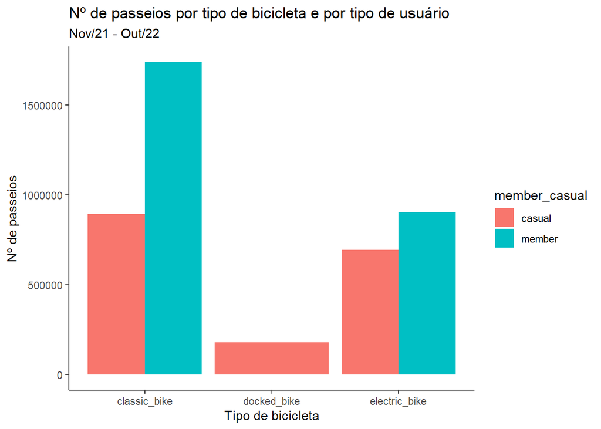

```r
dados_ano3 %>%
    group_by(member_casual, rideable_type) %>%
    summarise(number_of_rides = n()) %>%
    arrange(member_casual, rideable_type) %>%
    ggplot(aes(x = rideable_type, y = number_of_rides, fill = member_casual)) + geom_col(position = "dodge") + theme_classic() + labs(title = "Nº de passeios por tipo de bicicleta e por tipo de usuário",
                                                                                                                                      subtitle = "Nov/21 - Out/22", x = "Tipo de bicicleta", y = "Nº de passeios")
```

Fazendo o boxplot abaixo para avaliar o tempo de corrida, observamos que para as pessoas que são casuais, há bastante outlier. Quando fizemos o summary anteriormente, observamos que o valor mínimo é 1, média é 1.035 e o máximo é 2.061.244. Quando se trata de quem é membro, ainda encontramos outliers, porém não com casos discrepantes como em quem é casual.

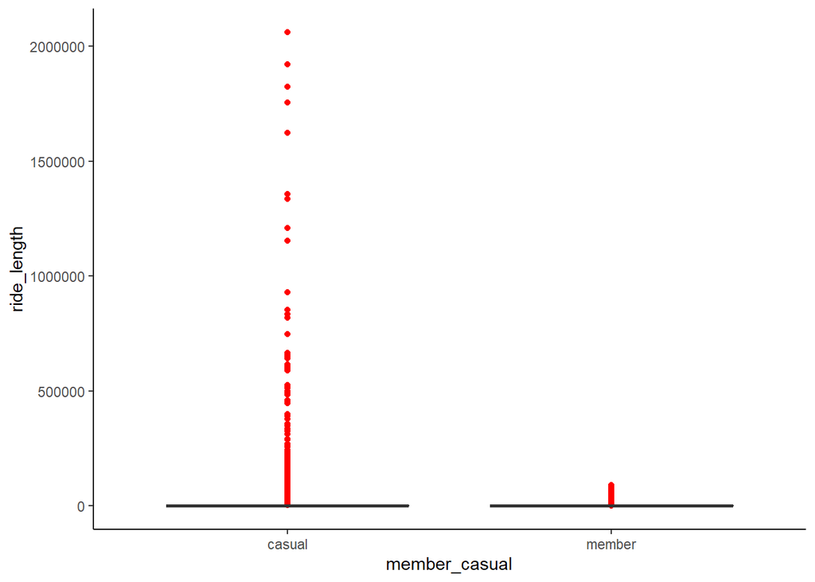

```r
ggplot(dados_ano3, aes(x=member_casual, y=ride_length)) + geom_boxplot(outlier.color="red") + theme_classic()
```

Para continuar a análise, resolvi retirar os outliers da base. Normalmente o cálculo do outlier é feito considerando 1.5, porém para esse estudo considerei 3 para retirar os casos bem extremos

```r
Interquartil <- (1147-365)*3
Limite_superior <- 1147 + Interquartil
Limite_inferior <- 365 - Interquartil

dados_ano4 <- filter(dados_ano3, ride_length <= Limite_superior & ride_length >= Limite_inferior)
```

Para efeito de comparação, farei os gráficos de barra anteriores novamente, porém considerando a retirada dos outliers para avaliar se há mudança de comportamento.

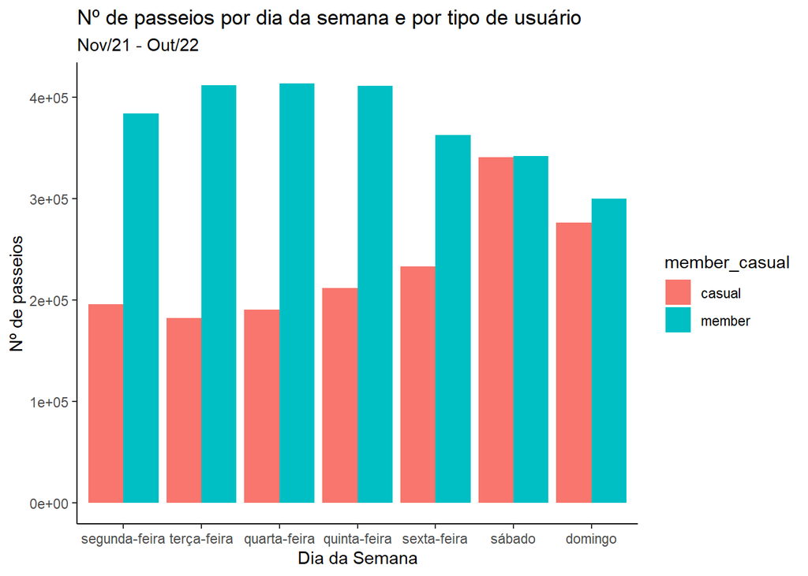

```r
dados_ano4 %>%
  group_by(member_casual, week_day) %>%
  summarise(number_of_rides = n()) %>%
  arrange(member_casual, week_day)  %>%
  ggplot(aes(x = week_day, y = number_of_rides, fill = member_casual)) + geom_col(position = "dodge") + theme_classic() + labs(title = "Nº de passeios por dia da semana e por tipo de usuário",
                                                                                                                               subtitle = "Nov/21 - Out/22", x = "Dia da Semana", y = "Nº de passeios")
```

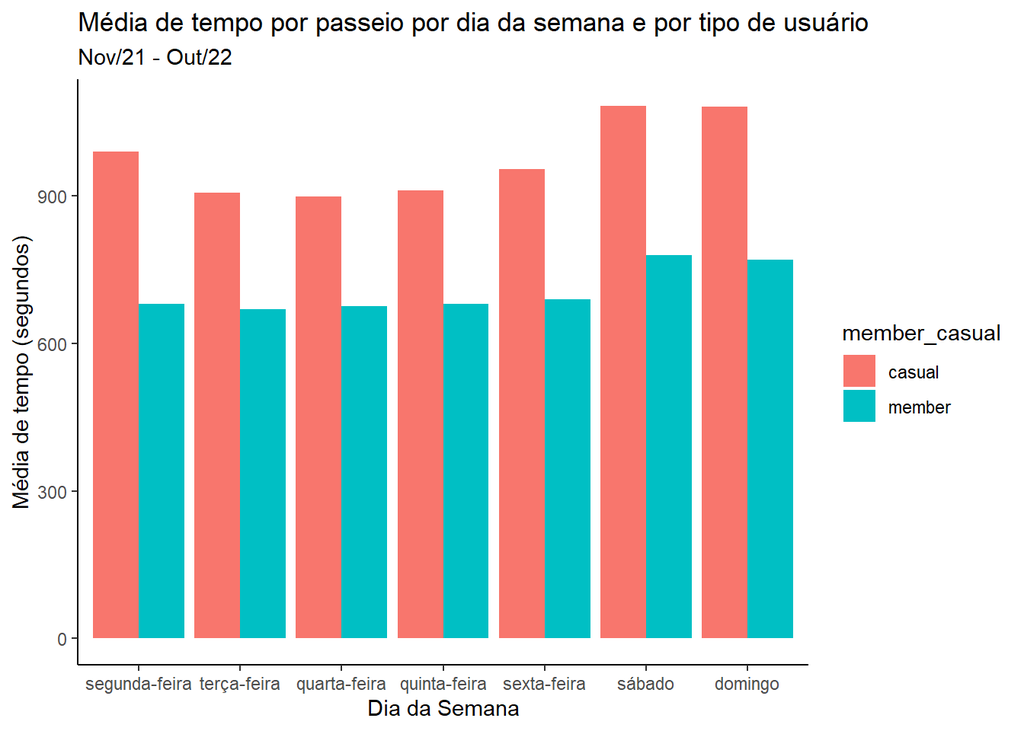

```r
dados_ano4 %>%
  group_by(member_casual, week_day) %>%
  summarise(average_duration = mean(ride_length)) %>%
  arrange(member_casual, week_day)  %>%
  ggplot(aes(x = week_day, y = average_duration, fill = member_casual)) + geom_col(position = "dodge") + theme_classic() + labs(title = "Média de tempo por passeio por dia da semana e por tipo de usuário",
                                                                                                                                subtitle = "Nov/21 - Out/22", x = "Dia da Semana", y = "Média de tempo (segundos)")
```

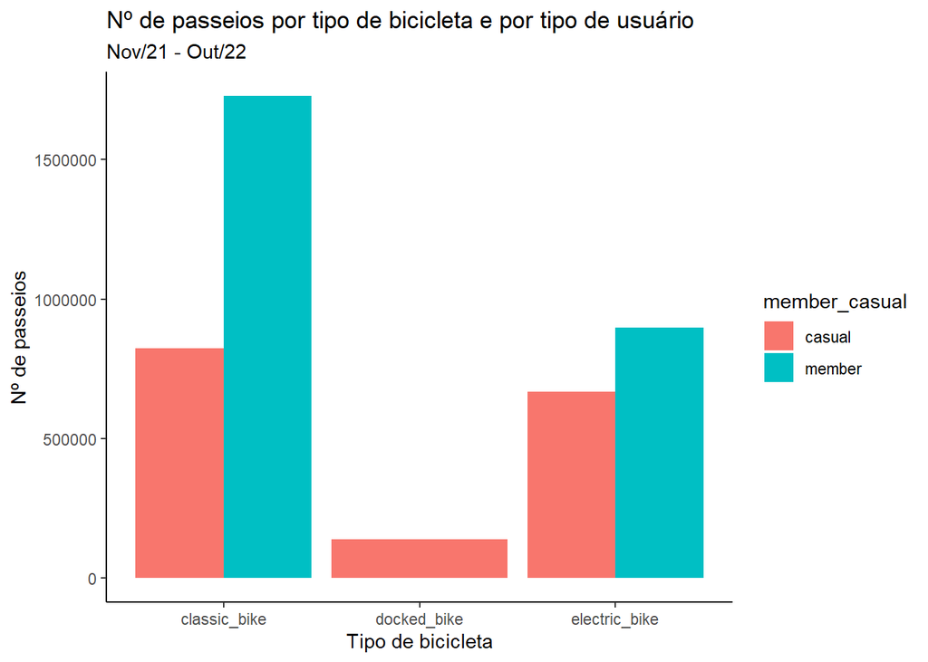

```r
dados_ano4 %>%
  group_by(member_casual, rideable_type) %>%
  summarise(number_of_rides = n()) %>%
  arrange(member_casual, rideable_type) %>%
  ggplot(aes(x = rideable_type, y = number_of_rides, fill = member_casual)) + geom_col(position = "dodge") + theme_classic() + labs(title = "Nº de passeios por tipo de bicicleta e por tipo de usuário",
                                                                                                                                    subtitle = "Nov/21 - Out/22", x = "Tipo de bicicleta", y = "Nº de passeios")
```

Não foram observadas grandes diferenças de comportamento. Apenas no sábado e domingo em relação ao número de passeios, onde antes de retirar os outliers, encontrávamos um resultado em que haviam mais pessoas casuais do que membros. Quando retiramos os outliers da base, nesses dois dias passamos a encontrar mais membros do que casual.

No boxplot abaixo ainda encontraremos alguns outliers, pois como falei, utilizei o multiplicador 3 ao invés de 1.5

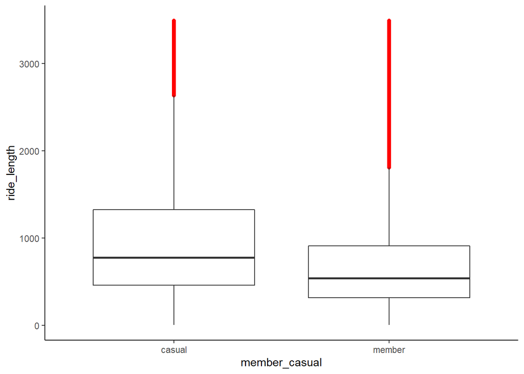

```r
ggplot(dados_ano4, aes(x=member_casual, y=ride_length)) + geom_boxplot(outlier.color="red") + theme_classic()
```

## Regressão logística Binomial

```r
dados_ano4$rideable_type <- as.factor(dados_ano4$rideable_type)
dados_ano4$member_casual <- as.factor(dados_ano4$member_casual)
dados_ano4$week_day <- as.factor(dados_ano4$week_day)
dados_ano4$month <- as.factor(dados_ano4$month)

str(dados_ano4)
```

```
## tibble [4,256,557 x 17] (S3: tbl_df/tbl/data.frame)
##  $ ride_id           : chr [1:4256557] "4CA9676997DAFFF6" "F3E84A230AF2D676" "A1F2C92308007968" "9B871C3B14E9BEC4" ...
##  $ rideable_type     : Factor w/ 3 levels "classic_bike",..: 1 1 3 1 1 3 3 3 3 3 ...
##  $ started_at        : POSIXct[1:4256557], format: "2021-11-26 10:27:28" "2021-11-15 09:35:03" ...
##  $ ended_at          : POSIXct[1:4256557], format: "2021-11-26 11:22:13" "2021-11-15 09:42:08" ...
##  $ start_station_name: chr [1:4256557] "Michigan Ave & Oak St" "Clark St & Grace St" "Leamington Ave & Hirsch St" "Desplaines St & Kinzie St" ...
##  $ start_station_id  : chr [1:4256557] "13042" "TA1307000127" "307" "TA1306000003" ...
##  $ end_station_name  : chr [1:4256557] "Michigan Ave & Oak St" "Clark St & Leland Ave" "Leamington Ave & Hirsch St" "Desplaines St & Kinzie St" ...
##  $ end_station_id    : chr [1:4256557] "13042" "TA1309000014" "307" "TA1306000003" ...
##  $ start_lat         : num [1:4256557] 41.9 42 41.9 41.9 41.9 ...
##  $ start_lng         : num [1:4256557] -87.6 -87.7 -87.8 -87.6 -87.6 ...
##  $ end_lat           : num [1:4256557] 41.9 42 41.9 41.9 41.9 ...
##  $ end_lng           : num [1:4256557] -87.6 -87.7 -87.8 -87.6 -87.6 ...
##  $ member_casual     : Factor w/ 2 levels "casual","member": 1 1 1 1 1 1 1 2 2 2 ...
##  $ ride_length       : num [1:4256557] 3285 425 2246 1181 1149 ...
##  $ week_day          : Ord.factor w/ 7 levels "segunda-feira"<..: 5 1 3 2 6 4 2 5 4 7 ...
##  $ month             : Factor w/ 12 levels "1","2","3","4",..: 11 11 11 11 11 11 11 11 11 11 ...
##  $ year              : num [1:4256557] 2021 2021 2021 2021 2021 ...
```

```r
levels(dados_ano4$member_casual) # Categoria de referência é Casual
```

```
## [1] "casual" "member"
```

```r
levels(dados_ano4$rideable_type) # Categoria de referência é Classic_bike
```

```
## [1] "classic_bike"  "docked_bike"   "electric_bike"
```

```r
levels(dados_ano4$week_day) # Categoria de referência é Segunda-feira
```

```
## [1] "segunda-feira" "terça-feira"   "quarta-feira"  "quinta-feira"
## [5] "sexta-feira"   "sábado"        "domingo"
```

```r
levels(dados_ano4$month) # Categoria de referência é Janeiro (1)
```

```
##  [1] "1"  "2"  "3"  "4"  "5"  "6"  "7"  "8"  "9"  "10" "11" "12"
```

```r
Regressao1 <- glm(dados_ano4$member_casual ~ dados_ano4$rideable_type + dados_ano4$ride_length + dados_ano4$week_day + dados_ano4$month, family = binomial(logit) , data=dados_ano4)
summary(Regressao1) # AIC 5.029.470
```

```
##
## Call:
## glm(formula = dados_ano4$member_casual ~ dados_ano4$rideable_type +
##     dados_ano4$ride_length + dados_ano4$week_day + dados_ano4$month,
##     family = binomial(logit), data = dados_ano4)
##
## Deviance Residuals:
##     Min       1Q   Median       3Q      Max
## -2.3280  -1.1964   0.7006   0.9315   2.0761
##
## Coefficients:
##                                         Estimate Std. Error  z value Pr(>|z|)
## (Intercept)                            2.365e+00  1.048e-02  225.680  < 2e-16
## dados_ano4$rideable_typedocked_bike   -1.695e+01  6.058e+00   -2.799 0.005128
## dados_ano4$rideable_typeelectric_bike -5.596e-01  2.214e-03 -252.743  < 2e-16
## dados_ano4$ride_length                -5.761e-04  1.723e-06 -334.364  < 2e-16
## dados_ano4$week_day.L                 -6.076e-01  2.874e-03 -211.367  < 2e-16
## dados_ano4$week_day.Q                 -2.419e-01  2.895e-03  -83.567  < 2e-16
## dados_ano4$week_day.C                  2.080e-01  2.857e-03   72.812  < 2e-16
## dados_ano4$week_day^4                  1.275e-01  2.816e-03   45.273  < 2e-16
## dados_ano4$week_day^5                  9.697e-02  2.845e-03   34.081  < 2e-16
## dados_ano4$week_day^6                  2.827e-02  2.851e-03    9.916  < 2e-16
## dados_ano4$month2                     -5.313e-02  1.415e-02   -3.754 0.000174
## dados_ano4$month3                     -7.178e-01  1.158e-02  -62.009  < 2e-16
## dados_ano4$month4                     -7.818e-01  1.130e-02  -69.213  < 2e-16
## dados_ano4$month5                     -1.203e+00  1.083e-02 -111.063  < 2e-16
## dados_ano4$month6                     -1.393e+00  1.073e-02 -129.883  < 2e-16
## dados_ano4$month7                     -1.373e+00  1.071e-02 -128.202  < 2e-16
## dados_ano4$month8                     -1.296e+00  1.074e-02 -120.705  < 2e-16
## dados_ano4$month9                     -1.172e+00  1.079e-02 -108.675  < 2e-16
## dados_ano4$month10                    -9.278e-01  1.093e-02  -84.847  < 2e-16
## dados_ano4$month11                    -6.017e-01  1.143e-02  -52.640  < 2e-16
## dados_ano4$month12                    -5.117e-01  1.194e-02  -42.870  < 2e-16
##
## (Intercept)                           ***
## dados_ano4$rideable_typedocked_bike   **
## dados_ano4$rideable_typeelectric_bike ***
## dados_ano4$ride_length                ***
## dados_ano4$week_day.L                 ***
## dados_ano4$week_day.Q                 ***
```

[output cut: 10 more lines]

```
## dados_ano4$month8                     ***
## dados_ano4$month9                     ***
## dados_ano4$month10                    ***
## dados_ano4$month11                    ***
## dados_ano4$month12                    ***
## ---
## Signif. codes:  0 '***' 0.001 '**' 0.01 '*' 0.05 '.' 0.1 ' ' 1
##
## (Dispersion parameter for binomial family taken to be 1)
##
##     Null deviance: 5667012  on 4256556  degrees of freedom
## Residual deviance: 5029428  on 4256536  degrees of freedom
## AIC: 5029470
##
## Number of Fisher Scoring iterations: 15
```

```r
Regressao2 <- glm(dados_ano4$member_casual ~ dados_ano4$rideable_type + dados_ano4$week_day + dados_ano4$month, family = binomial(logit) , data=dados_ano4)
summary(Regressao2) # AIC 5.145.301
```

```
##
## Call:
## glm(formula = dados_ano4$member_casual ~ dados_ano4$rideable_type +
##     dados_ano4$week_day + dados_ano4$month, family = binomial(logit),
##     data = dados_ano4)
##
## Deviance Residuals:
##     Min       1Q   Median       3Q      Max
## -2.1757  -1.2364   0.7409   0.9347   1.4065
##
## Coefficients:
##                                         Estimate Std. Error  z value Pr(>|z|)
## (Intercept)                             1.960309   0.010326  189.835  < 2e-16
## dados_ano4$rideable_typedocked_bike   -17.236987   6.226226   -2.768  0.00563
## dados_ano4$rideable_typeelectric_bike  -0.486755   0.002167 -224.589  < 2e-16
## dados_ano4$week_day.L                  -0.669055   0.002827 -236.666  < 2e-16
## dados_ano4$week_day.Q                  -0.283929   0.002849  -99.651  < 2e-16
## dados_ano4$week_day.C                   0.226008   0.002814   80.310  < 2e-16
## dados_ano4$week_day^4                   0.143920   0.002774   51.876  < 2e-16
## dados_ano4$week_day^5                   0.116197   0.002805   41.431  < 2e-16
## dados_ano4$week_day^6                   0.034063   0.002812   12.114  < 2e-16
## dados_ano4$month2                      -0.069456   0.014049   -4.944 7.66e-07
## dados_ano4$month3                      -0.799314   0.011478  -69.636  < 2e-16
## dados_ano4$month4                      -0.855687   0.011203  -76.381  < 2e-16
## dados_ano4$month5                      -1.327404   0.010744 -123.552  < 2e-16
## dados_ano4$month6                      -1.513805   0.010646 -142.190  < 2e-16
## dados_ano4$month7                      -1.491278   0.010631 -140.271  < 2e-16
## dados_ano4$month8                      -1.402356   0.010656 -131.599  < 2e-16
## dados_ano4$month9                      -1.257364   0.010709 -117.417  < 2e-16
## dados_ano4$month10                     -0.978851   0.010853  -90.188  < 2e-16
## dados_ano4$month11                     -0.642980   0.011343  -56.683  < 2e-16
## dados_ano4$month12                     -0.544753   0.011848  -45.978  < 2e-16
##
## (Intercept)                           ***
## dados_ano4$rideable_typedocked_bike   **
## dados_ano4$rideable_typeelectric_bike ***
## dados_ano4$week_day.L                 ***
## dados_ano4$week_day.Q                 ***
## dados_ano4$week_day.C                 ***
## dados_ano4$week_day^4                 ***
```

[output cut: 8 more lines]

```
## dados_ano4$month8                     ***
## dados_ano4$month9                     ***
## dados_ano4$month10                    ***
## dados_ano4$month11                    ***
## dados_ano4$month12                    ***
## ---
## Signif. codes:  0 '***' 0.001 '**' 0.01 '*' 0.05 '.' 0.1 ' ' 1
##
## (Dispersion parameter for binomial family taken to be 1)
##
##     Null deviance: 5667012  on 4256556  degrees of freedom
## Residual deviance: 5145261  on 4256537  degrees of freedom
## AIC: 5145301
##
## Number of Fisher Scoring iterations: 15
```

```r
Regressao3 <- glm(dados_ano4$member_casual ~ dados_ano4$rideable_type + dados_ano4$week_day, family = binomial(logit) , data=dados_ano4)
summary(Regressao3) # AIC 5.258.147
```

```
##
## Call:
## glm(formula = dados_ano4$member_casual ~ dados_ano4$rideable_type +
##     dados_ano4$week_day, family = binomial(logit), data = dados_ano4)
##
## Deviance Residuals:
##     Min       1Q   Median       3Q      Max
## -1.6569  -1.2958   0.7775   0.9446   1.2598
##
## Coefficients:
##                                         Estimate Std. Error  z value Pr(>|z|)
## (Intercept)                             0.764005   0.001361  561.560  < 2e-16
## dados_ano4$rideable_typedocked_bike   -17.243261   6.309028   -2.733  0.00627
## dados_ano4$rideable_typeelectric_bike  -0.465825   0.002125 -219.215  < 2e-16
## dados_ano4$week_day.L                  -0.700065   0.002780 -251.793  < 2e-16
## dados_ano4$week_day.Q                  -0.268140   0.002797  -95.883  < 2e-16
## dados_ano4$week_day.C                   0.221728   0.002773   79.973  < 2e-16
## dados_ano4$week_day^4                   0.142764   0.002734   52.209  < 2e-16
## dados_ano4$week_day^5                   0.110106   0.002767   39.798  < 2e-16
## dados_ano4$week_day^6                   0.031407   0.002775   11.319  < 2e-16
##
## (Intercept)                           ***
## dados_ano4$rideable_typedocked_bike   **
## dados_ano4$rideable_typeelectric_bike ***
## dados_ano4$week_day.L                 ***
## dados_ano4$week_day.Q                 ***
## dados_ano4$week_day.C                 ***
## dados_ano4$week_day^4                 ***
## dados_ano4$week_day^5                 ***
## dados_ano4$week_day^6                 ***
## ---
## Signif. codes:  0 '***' 0.001 '**' 0.01 '*' 0.05 '.' 0.1 ' ' 1
##
## (Dispersion parameter for binomial family taken to be 1)
##
##     Null deviance: 5667012  on 4256556  degrees of freedom
## Residual deviance: 5258129  on 4256548  degrees of freedom
## AIC: 5258147
##
## Number of Fisher Scoring iterations: 15
```

```r
Regressao4 <- glm(dados_ano4$member_casual ~ dados_ano4$rideable_type, family = binomial(logit) , data=dados_ano4)
summary(Regressao4) # AIC 5.347.402
```

```
##
## Call:
## glm(formula = dados_ano4$member_casual ~ dados_ano4$rideable_type,
##     family = binomial(logit), data = dados_ano4)
##
## Deviance Residuals:
##     Min       1Q   Median       3Q      Max
## -1.5033  -1.3051   0.8833   0.8833   1.0549
##
## Coefficients:
##                                         Estimate Std. Error  z value Pr(>|z|)
## (Intercept)                             0.739796   0.001339  552.583   <2e-16
## dados_ano4$rideable_typedocked_bike   -17.305865   6.428777   -2.692   0.0071
## dados_ano4$rideable_typeelectric_bike  -0.444583   0.002098 -211.883   <2e-16
##
## (Intercept)                           ***
## dados_ano4$rideable_typedocked_bike   **
## dados_ano4$rideable_typeelectric_bike ***
## ---
## Signif. codes:  0 '***' 0.001 '**' 0.01 '*' 0.05 '.' 0.1 ' ' 1
##
## (Dispersion parameter for binomial family taken to be 1)
##
##     Null deviance: 5667012  on 4256556  degrees of freedom
## Residual deviance: 5347396  on 4256554  degrees of freedom
## AIC: 5347402
##
## Number of Fisher Scoring iterations: 15
```

## Respondendo as perguntas do problema

1- Como os membros anuais e os ciclistas casuais usam as bicicletas ciclísticas de maneira diferente?

Observamos que os ciclistas casuais utilizam menos do que os membros tanto as bicicletas clássicas quanto as elétricas.

2- Por que os ciclistas casuais comprariam associações anuais ciclísticas?

Uma informação curiosa que podemos retirar da análise é que mesmo os ciclistas casuais tendo um número de passeios inferior do que os membros, os ciclistas casuais utilizam em média mais tempo do que os membros. Porém, podemos observar uma maior utilização por parte dos casuais em finais de semana, coisa que não acontece com os membros. Talvez esse comportamento se deve ao fato de que quem é membro, já deve ter uma rotina diária e um tempo cronometrado para essa atividade, por isso que o número de passeios durante a semana não varia tanto. Já os casuais, ainda não devem ter atribuido isso na sua rotina diária mas gosta da atividade a ponto de nos dias de lazer (finais de semana), utilizar mais as bicicletas. Logo, acredito que os ciclistas casuais comprariam associações anuais caso a empresa crie uma propaganda com foco nos finais de semana onde há um número maior desse público, incentivando e mostrando ser mais vantajoso a pessoa passar a ter essa rotina diária e mostrar que seria mais econômico ela participar do plano anual.

3- Como a Cyclistic pode usar a mídia digital para influenciar ciclistas casuais a se tornarem membros?

O marketing digital está em alta hoje em dia por mostrar o quão eficaz é em relação às propagandas tradicionais. Isso se deve à capacidade de direcionamento para o público alvo muito mais assertivamente do que as propagandas tradicionais. Com isso, poderiam ser filtradas as pessoas que buscam por equipamentos de esporte, principalmente para bicicleta, pessoas com uma faixa etária onde há maior probabilidade de realizar atividades físicas entre outras estratégias para potencializar o retorno do investimento feito na propaganda.